# ▒ 앙상블 ▒

### **0. 환경설정**

```r
# required_pkg        <- c("ipred", "gbm", "randomForest", "readxl")
# pkg_to_install      <- required_pkg[!(required_pkg %in% rownames(installed.packages()))]
# if(length(pkg_to_install) > 0) install.packages(pkg_to_install)

library(ipred)
library(gbm)
library(randomForest)
library(readxl)
```

**[Define function]** Boosting 횟수 M 정하기

```r
find_M <- function(m){
    fit.boost         <- gbm(as.factor(SGG)~.,data=train,distribution="multinomial",n.trees=m)
    pred.prob         <- predict(fit.boost,x_test,type="response",n.trees=m)  #확률로 나옴
    pred.prob         <- matrix(pred.prob, ncol = length(fit.boost$classes))
    pred              <- fit.boost$classes[apply(pred.prob,1,which.max)]
    err_rate          <- mean(pred!=y_test)
    return(err_rate)
}
```

### **1. 데이터 불러오기**

**[데이터 다운로드]**

- C드라이브에 [R_project] 폴더 생성
- [R_project] 폴더에 [DAT] 폴더 생성
- 데이터 스토어에서 샘플데이터(3.아파트_주소기반_주택지역특성시세정보_DB.xlsx)를 “C:/R_project/DAT/”에 다운로드 (https://www.datastore.or.kr/file/detail?id=2c0a9616-4d78-403c-9d77-3db2effb2a74&page=1&viewCount=10&sort=1&order=1&source=1&keyword=%EC%95%84%ED%8C%8C%ED%8A%B8)
- 서울/수도권 및 5대광역시 아파트에 대한 주소테이블 외 4개의 테이블(정보집단)로 구성되며 각각 주택특성정보, 지역특성정보, 가격/신뢰등급/예상회수율정보 테이블로 이루어져 있고, 각 테이블간은 고유키값(NUM)으로 연계되어 있음

**[데이터 호출]**

```r
path                  <- "data/3.아파트_주소기반_주택지역특성시세정보_DB.xlsx"
sheet.names           <- excel_sheets(path)

df1                   <- read_excel(path, sheet.names[1])
df2                   <- read_excel(path, sheet.names[2])
df3                   <- read_excel(path, sheet.names[3])
df4                   <- read_excel(path, sheet.names[4])
data                  <- Reduce(function(x, y) merge(x, y, all=FALSE), list(df1, df2, df3, df4))

data$LAND_ACCESS      <- as.numeric(as.character(data$LAND_ACCESS))
data$UNIT_NUM         <- as.numeric(as.character(data$UNIT_NUM))
data                  <- data[complete.cases(data), c("SGG","PRICE_GEN", "FLOOR", "PRIV_AREA", "PUB_AREA", "SUM_AREA","UNIT_NUM", "PARK_NUM", "LAND_ACCESS", "SUB_DIST")]

head(data, 5)
```

```
##      SGG PRICE_GEN FLOOR PRIV_AREA PUB_AREA SUM_AREA UNIT_NUM PARK_NUM
## 1 종로구    107000    14     94.51    66.27   160.78     1011     1480
## 2 종로구    124000    14    126.34    88.60   214.94     1011     1480
## 3 종로구    131000     2    147.31   103.30   250.61     1011     1480
## 4 종로구     70600     7    105.07    13.68   118.75       72        0
## 5 종로구    131000     6    140.78   100.84   241.62      462        0
##   LAND_ACCESS SUB_DIST
## 1     8920000      501
## 2     8920000      501
## 3     8920000      501
## 4    19000000      295
## 5    14500000      422
```

- SGG : 시군구
- PRICE_GEN ; 일반거래시세
- FLOOR : 층명
- PRIV_AREA : 전유면적
- PUB_AREA : 공유면적
- SUM_AREA : 계약 면적
- UNIT_NUM : 총세대수
- PARK_NUM : 총주차대수
- LAND_ACCESS : 개별공시지가
- SUB_DIST : 지하철역과의 거리

**[데이터 가공]** 데이터가 적은 지역 전처리 (광진구 제거, 종로구와 중구 통합)

```r
en_data               <- subset(data,!grepl("광진구", SGG))
en_data$SGG           <- ifelse(en_data$SGG == "성동구", "A",ifelse(en_data$SGG == "용산구", "B", "C"))
table(en_data$SGG)
```

```
##
##   A   B   C
## 224 115 124
```

```r
# column type 지정
en_data$SGG           <- as.factor(as.character(en_data$SGG))

head(en_data)
```

```
##   SGG PRICE_GEN FLOOR PRIV_AREA PUB_AREA SUM_AREA UNIT_NUM PARK_NUM LAND_ACCESS
## 1   C    107000    14     94.51    66.27   160.78     1011     1480     8920000
## 2   C    124000    14    126.34    88.60   214.94     1011     1480     8920000
## 3   C    131000     2    147.31   103.30   250.61     1011     1480     8920000
## 4   C     70600     7    105.07    13.68   118.75       72        0    19000000
## 5   C    131000     6    140.78   100.84   241.62      462        0    14500000
## 6   C    131000     6    140.78   100.84   241.62      462        0    14500000
##   SUB_DIST
## 1      501
## 2      501
## 3      501
## 4      295
## 5      422
## 6      422
```

**[데이터 분할]** Training set 70% , Test set 30% 무작위 추출을 이용하여 나누기

```r
set.seed(10)
sample_num            <- sample(1:nrow(en_data), 0.7*nrow(en_data))
train                 <- en_data[sample_num,]
test                  <- en_data[-sample_num,]
x_train               <- train[,-1]
x_test                <- test[,-1]
y_train               <- train[,1]
y_test                <- test[,1]
```

### **2. 앙상블**

**Bagging**

**[모형적합]** nbagg : bootstrap의 개수 (bootstrap의 개수는 충분히 크게 하는것이 좋다.)

```r
fit.bagg              <- ipredbagg(as.factor(y_train), x_train, data=train, nbagg=1000)
fit.bagg
```

```
##
## Bagging classification trees with 1000 bootstrap replications
```

**[예측]** 그룹예측

```r
pred                  <-predict(fit.bagg, newdata = x_test)
table(pred,y_test)
```

```
##     y_test
## pred  A  B  C
##    A 56  5  5
##    B  0 36  3
##    C  1  3 30
```

**[결과]** 오분류율

```r
cat("오분류율 = ", mean(pred!=y_test)*100,"%")
```

```
## 오분류율 =  12.23022 %
```

**[예측]** 확률예측

```r
pred2                <-predict(fit.bagg,x_test,type="prob")
head(pred2)
```

```
##          A     B     C
## [1,] 0.000 0.995 0.005
## [2,] 0.000 0.984 0.016
## [3,] 0.000 0.859 0.141
## [4,] 0.042 0.187 0.771
## [5,] 0.042 0.187 0.771
## [6,] 0.052 0.238 0.710
```

**Boosting : gbm(gradient boosting model)**

**[모형적합]**

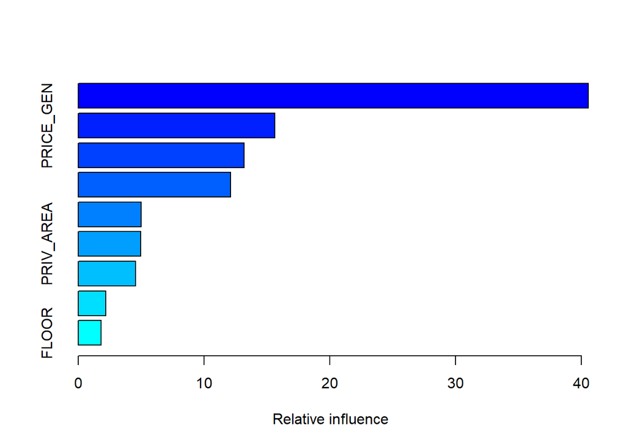

```
##                     var   rel.inf
## LAND_ACCESS LAND_ACCESS 40.536230
## PRICE_GEN     PRICE_GEN 15.632226
## UNIT_NUM       UNIT_NUM 13.166392
## SUB_DIST       SUB_DIST 12.103142
## PARK_NUM       PARK_NUM  5.017196
## PRIV_AREA     PRIV_AREA  4.980039
## PUB_AREA       PUB_AREA  4.565979
## SUM_AREA       SUM_AREA  2.189889
## FLOOR             FLOOR  1.808908
```

```r
fit.boost             <- gbm(SGG~.,data=train,distribution="multinomial",n.trees=500)
summary(fit.boost)
```

**[예측]** 확률예측

```r
pred.prob             <- predict(fit.boost,x_test,type="response",n.trees=500)    #확률로 나옴
pred.prob             <- matrix(pred.prob,ncol=3)                                 #3가지 범주의 확률
pred.prob
```

```
##                [,1]         [,2]         [,3]
##   [1,] 9.931384e-03 9.546981e-01 3.537048e-02
##   [2,] 7.959550e-03 8.981905e-01 9.384990e-02
##   [3,] 4.753698e-03 2.803672e-01 7.148791e-01
##   [4,] 8.172247e-03 1.360896e-01 8.557382e-01
##   [5,] 8.172247e-03 1.360896e-01 8.557382e-01
##   [6,] 3.782767e-03 1.920127e-02 9.770160e-01
##   [7,] 5.077467e-03 2.275177e-03 9.926474e-01
##   [8,] 2.463746e-03 3.257224e-03 9.942790e-01
##   [9,] 1.587153e-02 1.843043e-01 7.998242e-01
##  [10,] 4.287094e-03 3.845859e-01 6.111270e-01
##  [11,] 5.469924e-02 1.793165e-04 9.451214e-01
##  [12,] 7.927243e-02 1.935039e-04 9.205341e-01
##  [13,] 7.181855e-03 4.701739e-04 9.923480e-01
##  [14,] 8.364292e-04 1.097405e-01 8.894231e-01
```

[output cut: 125 more lines]

```r
# 각 범주에 속할 확률 산출
colnames(pred.prob)   <- levels(y_train)
head(pred.prob)
```

```
##                A          B          C
## [1,] 0.009931384 0.95469813 0.03537048
## [2,] 0.007959550 0.89819055 0.09384990
## [3,] 0.004753698 0.28036719 0.71487911
## [4,] 0.008172247 0.13608958 0.85573817
## [5,] 0.008172247 0.13608958 0.85573817
## [6,] 0.003782767 0.01920127 0.97701597
```

**[예측]** 3가지 범주중에 가장 높은 확률을 가진 범주로 분류

```r
pred                  <-apply(pred.prob,1,which.max)
pred                  <-ifelse(pred==1,"A",ifelse(pred==2,"B","C"))
table(pred,y_test)
```

```
##     y_test
## pred  A  B  C
##    A 55  1  2
##    B  1 42  2
##    C  1  1 34
```

**[결과]** 오분류율

```r
cat("오분류율 = ", mean(pred!=y_test)*100, "%")
```

```
## 오분류율 =  5.755396 %
```

**[Boosting 횟수 M 정하기]**

```r
find_M(50)
```

```
## [1] 0.1726619
```

```r
find_M(100)
```

```
## [1] 0.1582734
```

```r
find_M(250)
```

```
## [1] 0.08633094
```

```r
find_M(500)
```

```
## [1] 0.07913669
```

```r
find_M(750)
```

```
## [1] 0.0647482
```

```r
find_M(1000)
```

```
## [1] 0.07194245
```

```r
find_M(1500)
```

```
## [1] 0.07194245
```

```r
find_M(2000)
```

```
## [1] 0.07194245
```

**Random Forest**

**[모형적합]**

```r
set.seed(100)
fit.rf                <- randomForest(as.factor(SGG)~.,data=train, ntree=1000,  mtry=3)
```

**[예측]**

```r
pred                  <-predict(fit.rf,x_test)
table(pred,y_test)
```

```
##     y_test
## pred  A  B  C
##    A 55  2  4
##    B  1 38  3
##    C  1  4 31
```

**[결과]** 오분류율

```r
cat("오분류율 = ", mean(pred!=y_test)*100, "%")
```

```
## 오분류율 =  10.79137 %
```

**[random forest에서 k정하기]**

```r
MAPE                  <- NULL
for(i in 1:ncol(x_train)){
    temp_rf           <- randomForest(as.factor(SGG)~.,data=train, ntree=1000, mtry=i)
    pred              <- predict(temp_rf,x_test)
    MAPE[i]           <- mean(pred!=y_test)
}
round(MAPE,2)
```

```
## [1] 0.13 0.11 0.11 0.11 0.11 0.11 0.10 0.11 0.11
```

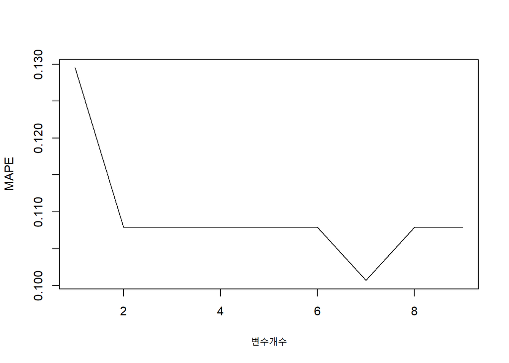

```r
plot(x=seq(1,ncol(x_train)),y=MAPE,type="l",xlab="변수개수")
```